# Tutorial 2

Você entra em um estágio de pesquisa no Centro de Estudos de Microfinanças e Inclusão Financeira (Cemif)1. Uma das pesquisadoras afiliadas ao Cemif te convida para trabalhar em um projeto de acesso a crédito de pequenas e médias empresas usando os dados do World Bank Enterprise Surveys (WBES)2, coletados no Brasil em 2009. A base de dados, brasil2009.csv, e o dicionário das variáveis estão na pasta do tutorial 2.

```r
library(tidyverse)
brasil <- read_csv("brasil2009.csv")
```

A pesquisadora diz que a base não foi tratada e precisa de alguns ajustes. Por exemplo, as respostas são codificadas com números negativos quando a(o) respondente não sabe (-9) ou se recusa a responder (-7). Para isso, você precisa transformar os números negativos em dados faltantes (NA). Um exemplo para fazer esta transformação usando o R está abaixo para a variável d2 (faturamento total anual). Vocês vão precisar usar o código abaixo para outras variáveis.

```r
brasil$d2 <- ifelse(brasil$d2 < 0, NA, brasil$d2)
```

A coordenadora do centro te pede um apoio. Ela está interessada em examinar o **impacto de investir em ativos fixos na produtividade do trabalho em pequenas e médias empresas (PMEs)**. Você nota que a variável produtividade do trabalho não está disponível na sua base de dados. No entanto, alguns estudos utilizam como proxy para produtividade o faturamento anual (variável d2) dividido pelo número de funcionários (variável l1 – leia- se letra l minúscula e número 1) (Amin e Okou, 2020; Motta, 2020; Kouamé e Tapsoba, 2019; Friesen e Wacker, 2019). Você cria essa variável

```r
brasil$l1 <- ifelse(brasil$l1 < 0, NA, brasil$l1)

brasil <- brasil %>%
  mutate(produtividade = d2/l1,
         logprodutividade = log(produtividade))

is.na(brasil) <- sapply(brasil, is.infinite) # transformando todos os - Inf # em missing data (NA)
```

*Verificar produtividade*

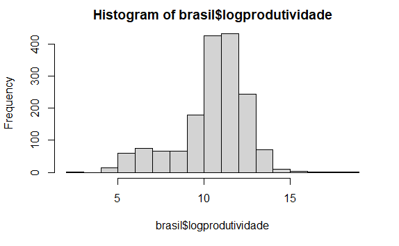

```r
hist(brasil$logprodutividade)
```

#### PERGUNTA 1

Você estima uma regressão simples do impacto da empresa ter realizado investimentos em ativos fixos (variável k4) no **logaritmo da produtividade da empresa**, e **interprete o resultado**. Na base, está variável dummy é igual a 1 para “Sim” e 2 para “Não”. Você ajusta essa variável e coloca 0 para “Não” ao invés de 2. (Dica: variáveis dummies são codificadas como 1 ou 0. Desta maneira, você vai ter que transformar o 2 (Não) em 0 além de transformar os números negativos em NAs)

```r
brasil$k4 <- ifelse(brasil$k4 < 0, NA, brasil$k4)
brasil$k4 <- ifelse(brasil$k4 == 2, 0, brasil$k4)

mqo <- lm(logprodutividade ~ k4, data = brasil)

summary(mqo)
```

```
Call:
lm(formula = logprodutividade ~ k4, data = brasil)

Residuals:
    Min      1Q  Median      3Q     Max
-7.6189 -0.6322  0.3329  1.2232  7.7262

Coefficients:
            Estimate Std. Error t value Pr(>|t|)
(Intercept) 10.14467    0.08933 113.563  < 2e-16 ***
k4           0.52451    0.10678   4.912  9.9e-07 ***
---
Signif. codes:  0 ‘***’ 0.001 ‘**’ 0.01 ‘*’ 0.05 ‘.’ 0.1 ‘ ’ 1

Residual standard error: 1.989 on 1651 degrees of freedom
  (149 observations deleted due to missingness)
Multiple R-squared:  0.0144,    Adjusted R-squared:  0.01381
F-statistic: 24.13 on 1 and 1651 DF,  p-value: 9.896e-07
```

**Resposta:** ??A interpretacao muda, pois nao tenho mais y, tenho log(y), assim um aumento de uma unidade de x nao leva a um aumento esperado de b1 em y. Aumentar 1 unidade X leva um aumento relativo de b1*100% em y ??(Comentários: Em caso de modelo linear log, onde y se mantém e o log ocorre nas variáveis independentes Interpretacao aproximada/relativa. aumentar 1% induz um aumento ou diminuicao de b1/100 unidades em y)

Entao a análise da mudanca é `y = b0 + b1x1`

y = log(produtividade) x = realizacao de investimento

log(produtividade) = 10,14 + 0.52*100x

Entao, para caso ocorra investimentos em ativos fixos, o aumento relativo da produtividade é em 52%

#### PERGUNTA 2

Você mostra o resultado acima para a coordenadora e ela comenta que você não pode fazer afirmações sobre o efeito do investimento na produtividade sem considerar que você está trabalhando apenas com uma amostra. Você não entende bem o que ela quer dizer e ela te sugere fazer uma pesquisa sobre p-valores e o teste t para coeficientes de regressão. Você interpreta o coeficiente do investimento e teste hipótese nula

𝐻0 : 𝛽𝑖𝑛𝑣𝑒𝑠𝑡𝑖𝑚𝑒𝑛𝑡𝑜 = 0 contra a hipótese alternativa 𝐻𝑎 : 𝛽𝑖𝑛𝑣𝑒𝑠𝑡𝑖𝑚𝑒𝑛𝑡𝑜 ≠ 0 .

Qual o valor da estatística t? Podemos rejeitar a hipótese nula para um nível de significância de 5%?

**Resposta:** H0 significa que o investimento nao foi feito H1 significa que o investimento foi feito

```r
t.test(logprodutividade ~ k4, data = brasil)
```

```
    Welch Two Sample t-test

data:  logprodutividade by k4
t = -4.7579, df = 872.9, p-value = 2.288e-06
alternative hypothesis: true difference in means between group 0 and group 1 is not equal to 0
95 percent confidence interval:
 -0.7408718 -0.3081449
sample estimates:
mean in group 0 mean in group 1
       10.14467        10.66918
```

O p-valor é inferior a 5%, logo quem recebe investimento e quem nao recebe possui diferenca significativa entre as médias. Podemos assumir a hipótese H0 como falsa.

#### PERGUNTA 3

A pesquisadora do Cemif sugere que você inclua outras variáveis de controle no seu modelo. Ela sugere dar uma olhada no paper Islam, Gaddis, Palacios López e Amin (2020) para ter ideias sobre potenciais variáveis de controle. **Por exemplo,a idade da empresa pode estar associada à produtividade**. No entanto, a base possui apenas o ano em que a empresa iniciou sua operação (b5). Você uma variável de idade da firma igual a diferença entre o ano fiscal atual (2007) e o ano em que a empresa iniciou sua operação. **Além da idade, você coloca outras variáveis de controle que podem impactar a produtividade do trabalho da firma**

```r
brasil$b5 <- ifelse(brasil$b5 < 0, NA, brasil$b5)

brasil <- brasil %>%
  mutate(idade_firma = 2007-b5)
```

Rodando o modelo

```r
mqo2 <- lm(logprodutividade ~ k4+idade_firma, data = brasil)

summary(mqo)
```

[output not shown]

#### PERGUNTA 4

Conhecendo o conceito de p-valor, você observa que a saída do R do resumo do modelo na questão anterior apresenta, além dos testes t para os coeficientes, um teste F para o modelo como um todo. Para completar seu relatório deste primeiro projeto, você vai pesquisar sobre esse teste F. Qual a hipótese nula do teste? Como interpretar a rejeição ou não-rejeição desse teste?

**Resposta:** Teste-f é usado para comparar a variancia. Comparar a variancia entre grupos, quadrado médio dos resíduos.

Comparar a variancia de dois grupos. Exige normalidade dos dados quando homogeneidade de variancia. H0 x e y possuem a mesma variancia?

Rejeitamos um H0 quando o valor do pvalor é menor que 1%

```r
var.test()
```

#### PERGUNTA 5

Você nota que na saída do R do resumo do modelo aparece uma coluna denominada erro padrão (Std. Error). Um outro estudante não entende muito bem o que é o erro-padrão e você explica para ele, falando também sobre a relação do erro padrão com o p-valor dos testes t.

**Resposta:**

#### PERGUNTA 6

O gênero da(o) proprietária(o) pode ser um preditor do faturamento anual, pois existem diferenças no faturamento entre empresas lideradas por mulheres e homens (Islam, Gaddis, Palacios López e Amin, 2020). Você cria a variável binária (dummy) igual a 1 se existe ao menos uma mulher proprietária (b4) no modelo de regressão anterior e sugere que talvez seja interessante estimar se o impacto de um ano a mais de experiência em gestão (b7) na produtividade do trabalho é o mesmo para mulheres e homens em cargos de direção (b7a). Você estima o modelo abaixo:

log(𝑝𝑟𝑜𝑑𝑢𝑡𝑖𝑣𝑖𝑑𝑎𝑑𝑒) = 𝛽0 + 𝛽1𝑒𝑥𝑝 + 𝛽2𝑚𝑢𝑙ℎ𝑒𝑟 + 𝛽3𝑒𝑥𝑝 ∗ 𝑚𝑢𝑙ℎ𝑒𝑟

onde log(faturamento) é o logaritmo natural do faturamento anual, exp é a experiência do(a) gestor (a) na área de atuação (em anos), e mulher é uma variável dummy igual a 1 se a diretora principal for mulher (0 caso contrário). Você interpreta o coeficiente do termo de interação entre experiência e mulher

```r
brasil$b7a <- ifelse(brasil$b7a < 0, NA, brasil$b7a)
brasil$b7a <- ifelse(brasil$b7a == 2, 0, brasil$b7a)

brasil$b7 <- ifelse(brasil$b7 < 0, NA, brasil$b7)

brasil <- brasil %>%
  mutate(logfaturamento = log(d2))
```

Modelo

```r
mqo3 <- lm(logfaturamento ~ b7 + b7a + I(b7*b7a), data = brasil)
summary(mqo3)
```

```
Call:
lm(formula = logfaturamento ~ b7 + b7a + I(b7 * b7a), data = brasil)

Residuals:
    Min      1Q  Median      3Q     Max
-7.2733 -1.3472  0.0203  1.6340  7.5049

Coefficients:
             Estimate Std. Error t value Pr(>|t|)
(Intercept) 13.439502   0.148034  90.786  < 2e-16 ***
b7           0.034759   0.005746   6.050 1.79e-09 ***
b7a         -0.608836   0.343446  -1.773   0.0765 .
I(b7 * b7a) -0.015291   0.015021  -1.018   0.3088
---
Signif. codes:  0 ‘***’ 0.001 ‘**’ 0.01 ‘*’ 0.05 ‘.’ 0.1 ‘ ’ 1

Residual standard error: 2.494 on 1654 degrees of freedom
  (144 observations deleted due to missingness)
Multiple R-squared:  0.04312,   Adjusted R-squared:  0.04139
F-statistic: 24.85 on 3 and 1654 DF,  p-value: 1.006e-15
```

**Resposta:**

#### PERGUNTA 7

Uma estudante em fase de término mestrado acadêmico comenta com o grupo que sua dissertação consiste em examinar o impacto da competição no mercado informal no faturamento da empresa. Um estudo mostra que pequenas e médias empresas (PMEs) são as mais afetadas pela competição com empresas informais (González e Lamanna, 2007; Distinguin et al, 2016). A pesquisadora acha interessante e pede para você estimar o modelo abaixo:

```r
brasil$e11 <- ifelse(brasil$e11 < 0, NA, brasil$e11)
brasil$e11 <- ifelse(brasil$e11 == 2, 0, brasil$e11)

brasil <- brasil %>%
  mutate(pme = case_when(l1 < 100 ~ 1,
                         TRUE ~ 0))
```

Modelo

```r
mqo4 <- lm(logprodutividade ~ e11 + pme + I(e11*pme), data = brasil)
summary(mqo4)
```

```
Call:
lm(formula = logprodutividade ~ e11 + pme + I(e11 * pme), data = brasil)

Residuals:
    Min      1Q  Median      3Q     Max
-8.3840 -0.5910  0.4271  1.2025  6.8305

Coefficients:
             Estimate Std. Error t value Pr(>|t|)
(Intercept)  10.81190    0.16637  64.986   <2e-16 ***
e11           0.09782    0.21952   0.446   0.6559
pme          -0.16877    0.19334  -0.873   0.3829
I(e11 * pme) -0.43479    0.24979  -1.741   0.0819 .
---
Signif. codes:  0 ‘***’ 0.001 ‘**’ 0.01 ‘*’ 0.05 ‘.’ 0.1 ‘ ’ 1

Residual standard error: 1.99 on 1619 degrees of freedom
  (179 observations deleted due to missingness)
Multiple R-squared:  0.01349,   Adjusted R-squared:  0.01166
F-statistic: 7.378 on 3 and 1619 DF,  p-value: 6.553e-05
```

x: 0 nao compete com empresas informais , 1 compete com empresas informais z: 0 grande, 1 pme

`y = B0 + B1x + B2z + B3xz`

nao compete e é grande y = B0 nao compete e é pme: y = B0 + B2 compete e é grande: y = B0 + B1 compete e é pme: y = B0 + B1 + B2 + B3

##### PERGUNTA 7a

PMEs que não competem no mercado informal

##### PERGUNTA 7b

Empresas grandes que competem no mercado informal

##### PERGUNTA 7c

Empresas grandes que não competem no mercado informal